# CIND 123 - Data Analytics: Basic Methods

Stephanie Boissonneault

# Assignment 2 (10%)

### [Stephanie Boissonneault]

## Instructions

Use RStudio for this assignment. Complete the assignment by inserting your R code wherever you see the string “#INSERT YOUR ANSWER HERE”.

Submit **both** the rmd and generated output files. Failing to submit both files will be subject to mark deduction.

## Sample Question and Solution

Use `seq()` to create the vector $(100,97\ldots,4)$.

```r
seq(100, 3, -3)
```

```
##  [1] 100  97  94  91  88  85  82  79  76  73  70  67  64  61  58  55  52  49  46
## [20]  43  40  37  34  31  28  25  22  19  16  13  10   7   4
```

## Question 1 (40 points)

The Titanic Passenger Survival Data Set provides information on the fate of passengers on the fatal maiden voyage of the ocean liner “Titanic.” The dataset is available from the Department of Biostatistics at the Vanderbilt University School of Medicine (https://biostat.app.vumc.org/wiki/pub/Main/DataSets/titanic3.csv) in several formats. Store the Titanic Data Set `titanic_train` using the following commands.

```r
#install.packages("titanic")
library(titanic)
titanicDataset <- read.csv(file = "https://biostat.app.vumc.org/wiki/pub/Main/DataSets/titanic3.csv", stringsAsFactors = F)
str(titanicDataset)
```

```
## 'data.frame':    1309 obs. of  14 variables:
##  $ pclass   : int  1 1 1 1 1 1 1 1 1 1 ...
##  $ survived : int  1 1 0 0 0 1 1 0 1 0 ...
##  $ name     : chr  "Allen, Miss. Elisabeth Walton" "Allison, Master. Hudson Trevor" "Allison, Miss. Helen Loraine" "Allison, Mr. Hudson Joshua Creighton" ...
##  $ sex      : chr  "female" "male" "female" "male" ...
##  $ age      : num  29 0.92 2 30 25 48 63 39 53 71 ...
##  $ sibsp    : int  0 1 1 1 1 0 1 0 2 0 ...
##  $ parch    : int  0 2 2 2 2 0 0 0 0 0 ...
##  $ ticket   : chr  "24160" "113781" "113781" "113781" ...
##  $ fare     : num  211 152 152 152 152 ...
##  $ cabin    : chr  "B5" "C22 C26" "C22 C26" "C22 C26" ...
##  $ embarked : chr  "S" "S" "S" "S" ...
##  $ boat     : chr  "2" "11" "" "" ...
##  $ body     : int  NA NA NA 135 NA NA NA NA NA 22 ...
##  $ home.dest: chr  "St Louis, MO" "Montreal, PQ / Chesterville, ON" "Montreal, PQ / Chesterville, ON" "Montreal, PQ / Chesterville, ON" ...
```

1. Extract and show the columns `cabin`, `age`, `embarked` and `pclass` into a new data frame of the name ‘titanicSubset’. (5 points)

```r
titanicSubset <- data.frame(titanicDataset$cabin, titanicDataset$age, titanicDataset$embarked, titanicDataset$pclass)

print(str(titanicSubset))
```

```
## 'data.frame':    1309 obs. of  4 variables:
##  $ titanicDataset.cabin   : chr  "B5" "C22 C26" "C22 C26" "C22 C26" ...
##  $ titanicDataset.age     : num  29 0.92 2 30 25 48 63 39 53 71 ...
##  $ titanicDataset.embarked: chr  "S" "S" "S" "S" ...
##  $ titanicDataset.pclass  : int  1 1 1 1 1 1 1 1 1 1 ...
## NULL
```

2. Numerical data: Use the count() function from the `dplyr` package to display the total number of passengers that survived or not. (5 points) HINT: To count the occurrences of survived or not in the titanicDataset data frame using the `dplyr` package, you can use the pipe operator (%>%) to chain operations.

```r
#install.packages('dplyr')
library(dplyr)
print(titanicDataset %>% count(survived))
```

```
##   survived   n
## 1        0 809
## 2        1 500
```

3. Categorical data: Use count() and group_by() functions from the `dplyr` package to calculate the number of passengers by `embarked`. (5 points) HINT: Use group_by() first then pipe the result to count() to calculate the number of passengers.

```r
n_embarked <- group_by(titanicDataset %>% count(embarked))
n_embarked
```

```
## # A tibble: 4 × 2
##   embarked     n
##   <chr>    <int>
## 1 ""           2
## 2 "C"        270
## 3 "Q"        123
## 4 "S"        914
```

4. Find the passengers in data frame whose embarked information is an empty character (““), and fill them by the most frequent embarked value. (3 points)

```r
#Most frequent embarked value is "S"
for (i in 1:length(titanicDataset$embarked)) {
  if (titanicDataset$embarked[i] == "")
     {titanicDataset$embarked[i] <- "S"}
}

print(titanicDataset$embarked)
```

[output not shown]

[output cut: 58 more lines]

5. Use the aggregate() function to calculate the ‘survivalCount’ of each `embarked` and calculate the survival rate of each embarked. Then draw the conclusion on which embarked has the higher survival rate. (5 points)

```r
survivalCount <- aggregate(survived ~ embarked, data=titanicDataset, FUN = sum)
survivalCount
```

```
##   embarked survived
## 1        C      150
## 2        Q       44
## 3        S      306
```

```r
#Calculate the survival rate of each embarked
survivalLength <- aggregate(survived ~ embarked, data=titanicDataset, FUN = length)

survivalRate <- survivalCount$survived/survivalLength$survived

#Survival rates are:
cbind(survivalCount$embarked, survivalRate)
```

```
##          survivalRate
## [1,] "C" "0.555555555555556"
## [2,] "Q" "0.357723577235772"
## [3,] "S" "0.334061135371179"
```

```r
print("Embarked C has the highest survival rates")
```

```
## [1] "Embarked C has the highest survival rates"
```

6. Use boxplot to display the distribution of fare for each pclass and infer which passenger class is more expensive. (5 points)

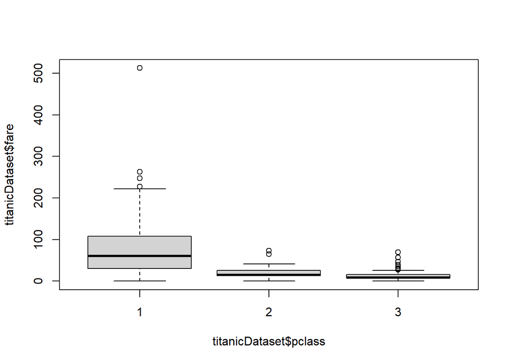

```r
#Boxplot wit outliers
boxplot(titanicDataset$fare ~ titanicDataset$pclass)
```

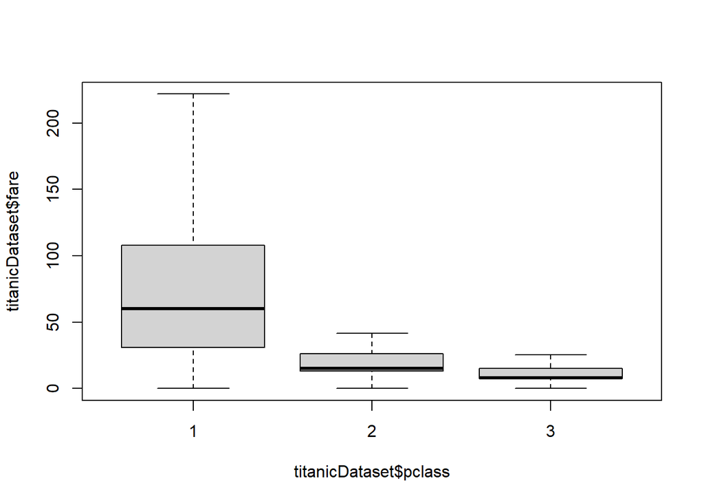

```r
#Boxplot without outliers
boxplot(titanicDataset$fare ~ titanicDataset$pclass, outline = FALSE)
```

```r
print("The most expensive pclass is class 1")
```

```
## [1] "The most expensive pclass is class 1"
```

7. Calculate the average fare for three pclass and describe if the calculation agrees with the box plot. (5 points)

```r
index_class1 <- which(titanicDataset$pclass == 1)
index_class2 <- which(titanicDataset$pclass == 2)
index_class3 <- which(titanicDataset$pclass == 3)

avg_fare_class1 <- mean(titanicDataset$fare[index_class1], na.rm = TRUE)
avg_fare_class2 <- mean(titanicDataset$fare[index_class2], na.rm = TRUE)
avg_fare_class3 <- mean(titanicDataset$fare[index_class3], na.rm = TRUE)

avg_fare_class1
```

```
## [1] 87.50899
```

```r
avg_fare_class2
```

```
## [1] 21.1792
```

```r
avg_fare_class3
```

```
## [1] 13.30289
```

```r
print("The calculated average fare for reach class agrees with findings from the boxplot. The average fare of class 1 is the highest, followed by class 2, and lastly class three.")
```

```
## [1] "The calculated average fare for reach class agrees with findings from the boxplot. The average fare of class 1 is the highest, followed by class 2, and lastly class three."
```

8. Use the for loop and if control statements to list the mens’s non-empty home destinations, age 54 or less that embarked from Q (Queenstown), on the Titanic. (7 points)

```r
#Cleaning data by converting empty strings to NA
cleanData <- titanicDataset
cleanData[cleanData == ""] <- NA

homeDest <- list()
for (i in 1:length(cleanData$sex)) {
  if (cleanData$sex[i] == "male" &
      !is.na(cleanData$home.dest[i]) &
      !is.na(cleanData$age[i]) &
      cleanData$age[i] <= 54 &
      cleanData$embarked[i] == "Q"){
      homeDest<- append(homeDest,cleanData$home.dest[i])}
}

print(homeDest)
```

```
## [[1]]
## [1] "Fond du Lac, WI"
##
## [[2]]
## [1] "Ireland Chicago, IL"
##
## [[3]]
## [1] "Kingwilliamstown, Co Cork, Ireland New York, NY"
##
## [[4]]
## [1] "Co Cork, Ireland Charlestown, MA"
##
## [[5]]
## [1] "Ireland Philadelphia, PA"
##
## [[6]]
## [1] "Ireland New York, NY"
##
## [[7]]
## [1] "Co Limerick, Ireland Sherbrooke, PQ"
##
## [[8]]
## [1] "Philadelphia, PA"
##
## [[9]]
## [1] "Ireland Brooklyn, NY"
##
## [[10]]
## [1] "Co Athlone, Ireland New York, NY"
##
## [[11]]
## [1] "Ireland New York, NY"
##
## [[12]]
## [1] "Aughnacliff, Co Longford, Ireland New York, NY"
##
## [[13]]
## [1] "Ireland Chicago, IL"
##
## [[14]]
## [1] "New York, NY"
```

## Question 2 (15 points)

80 engines work together in a sequence. The historical data shows that the probability of each engine’s failure is 0.05. We know that if one engine fails, the whole system stops.

1. What is the probability that the system operates without failure? (5 points)

```r
# If the probability of each engine's failure is 0.05, the probability of each engine working (not failing) is 0.95.

#For the system to work, all engines must work, therefore looking for intersection of all 80 engines working

#When A and B are independent A∩B = (A)(B), therefore multiply the probability of success of each of the 80 engines working to determine success rate of whole system:

prob_all_engines_work<- 0.95^80
prob_all_engines_work
```

```
## [1] 0.01651537
```

2. Use the Binomial approximation to calculate the probability that at least 3 engines are defective? (5 points)

```r
1 - pbinom( q= 2, size = 80, prob = 0.05)
```

```
## [1] 0.7693795
```

3. What is the probability that the second engine (B) is defective given the first engine (A) is not defective, i.e., P(B is defective|A is not defective), while we know that the first and second engines are independent. (5 points)

```r
#P(B is defective|A is not defective)
#When A and B are independent, P(B|A) = P(B)
#Therefore P(B is defective) = 0.05

print("P(B is defective|A is not defective) = 0.05")
```

```
## [1] "P(B is defective|A is not defective) = 0.05"
```

## Question 3 (25 points)

On average, John visits his parents 4 times a month

1. Find the probabilities that John visits his parents 1 to 6 times in a month? (5 points)

```r
#probabilities John visits P(1), P(2), P(3), P(4), P(5) and P(6) times in a month
dpois(1:6, 4)
```

```
## [1] 0.07326256 0.14652511 0.19536681 0.19536681 0.15629345 0.10419563
```

2. Find the probability that John visits his parents 3 times or more in a month? (5 points)

```r
ppois(2, 4, lower = FALSE)
```

```
## [1] 0.7618967
```

3. Compare the similarity between Binomial and Poisson distribution. (15 points @ 5 point each)
1. Create 100,000 samples for a Binomial random variable using parameters described in Question 2
2. Create 100,000 samples for a Poisson random variable using parameters described in Question 3
3. then illustrate on how well the Poisson probability distribution approximates the Binomial probability distribution. HINT: use multhist() from the ‘plotrix’ package

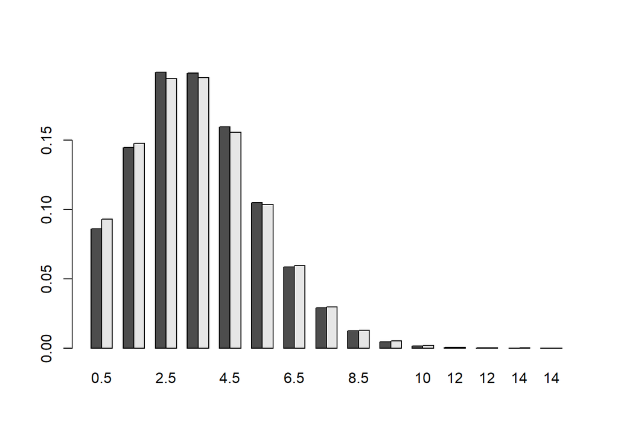

```r
#1) Parameters in Question 2 (Size = 80, Prob of failure = 0.05)

binomSample <- rbinom(100000, 80, 0.05)
#binomSample


#2) Parameters in Question 3 (lambda = 4)

poisSample <- rpois(100000, 4)
#poisSample

#3) then illustrate on how well the Poisson probability distribution approximates the Binomial probability distribution. HINT: use multhist() from the 'plotrix' package

#install.packages("plotrix")
library("plotrix")
binom_and_pois_hist <-multhist(list(binomSample, poisSample), freq = F)
```

```r
binom_and_pois_hist
```

```
## [[1]]
## $breaks
##  [1]  0  1  2  3  4  5  6  7  8  9 10 11 12 13 14 15
##
## $counts
##  [1] 17905 29238 39396 39371 31558 20854 11800  5859  2548   946   364   118
## [13]    27    14     2
##
## $density
##  [1] 0.089525 0.146190 0.196980 0.196855 0.157790 0.104270 0.059000 0.029295
##  [9] 0.012740 0.004730 0.001820 0.000590 0.000135 0.000070 0.000010
##
## $mids
##  [1]  0.5  1.5  2.5  3.5  4.5  5.5  6.5  7.5  8.5  9.5 10.5 11.5 12.5 13.5 14.5
##
## $xname
## [1] "unlist(x)"
##
## $equidist
## [1] TRUE
##
## attr(,"class")
## [1] "histogram"
##
## [[2]]
##         [,1]    [,2]    [,3]    [,4]    [,5]    [,6]    [,7]    [,8]    [,9]
## [1,] 0.08613 0.14470 0.19923 0.19843 0.15969 0.10488 0.05858 0.02895 0.01262
## [2,] 0.09292 0.14768 0.19473 0.19528 0.15589 0.10366 0.05942 0.02964 0.01286
##        [,10]   [,11]   [,12]   [,13] [,14] [,15]
## [1,] 0.00441 0.00166 0.00055 0.00012 5e-05 0e+00
## [2,] 0.00505 0.00198 0.00063 0.00015 9e-05 2e-05
```

```r
print("As illustrated in the histrogram, the Poisson probability distribution approximates the Binomial probability distribution.")
```

```
## [1] "As illustrated in the histrogram, the Poisson probability distribution approximates the Binomial probability distribution."
```

## Question 4 (20 points)

Write a script in R to compute the following probabilities of a normal random variable with mean 9 and variance 25

1. The probability that it lies between 8.2 and 17.3 (inclusive) (5 points)

```r
#mean = 9
#variance = 25
#standard deviation = 5
my_sd = sqrt(25)
my_sd
```

```
## [1] 5
```

```r
prob_q4a <- pnorm(17.3, mean = 9, sd = 5) - pnorm(8.2, mean = 9, sd = 5)
prob_q4a
```

```
## [1] 0.5151022
```

2. The probability that it is greater than 15.02 (5 points)

```r
prob_q4b <- pnorm(15.02, mean = 9, sd = 5, lower.tail = FALSE)
prob_q4b
```

```
## [1] 0.1142948
```

3. The probability that it is less than or equal to 11.8 (5 points)

```r
prob_q4c <- pnorm(11.8, mean = 9, sd = 5, lower.tail = TRUE)
prob_q4c
```

```
## [1] 0.7122603
```

4. The probability that it is less than 10 or greater than 13 (5 points)

```r
prob_q4d <- pnorm(10, mean = 9, sd = 5, lower.tail = TRUE) + pnorm(13, mean = 9, sd = 5, lower.tail = FALSE)
prob_q4d
```

```
## [1] 0.7911151
```

END of Assignment #2.